# foodCluster

--- title: Clustering example ---

Let's see if we can reasonably cluster our survey respondants based on their food preferences. First, I have to separate out the food columns from everything else.

```python
import pandas as pd
import numpy as np
from sklearn.cluster import KMeans
import matplotlib.pyplot as plt
import plotly.graph_objects as go
```

```python
df=pd.read_csv('../datasets/foodsAndMovies.csv.gz')
print(df.columns)
```

```
Index(['Timestamp', 'I am a:', 'I identify as:', 'Broccoli', 'Mushrooms',
       'Beef Tacos', 'Salads', 'Black Licorice', 'Steak', 'Grilled Chicken',
       'Mayonnaise', 'Candy Corn', 'Pulled Pork', 'Spicy Mustard',
       'Raw Oysters', 'Bananas', 'Avocado', 'Eggs', 'Olives', 'Tofu',
       'Cottage Cheese', 'Black Panther', 'Pitch Perfect',
       'Star Wars: The Last Jedi', 'It', 'The Big Sick', 'Lady Bird',
       'Pirates of the Caribbean', 'Despicable Me', 'Coco', 'John Wick',
       'Mamma Mia', 'Crazy Rich Asians',
       'Three Billboards Outside Ebbings, Missouri', 'The Incredibles'],
      dtype='object')
```

```python
foodFrame = df[['Broccoli', 'Mushrooms', 'Beef Tacos', 'Salads', 'Black Licorice', 'Steak', 'Grilled Chicken', 'Mayonnaise', 'Candy Corn', 'Pulled Pork', 'Spicy Mustard', 'Raw Oysters', 'Bananas', 'Avocado', 'Eggs', 'Olives', 'Tofu', 'Cottage Cheese']]
print(foodFrame.columns)
foodFrame.head()
```

```
Index(['Broccoli', 'Mushrooms', 'Beef Tacos', 'Salads', 'Black Licorice',
       'Steak', 'Grilled Chicken', 'Mayonnaise', 'Candy Corn', 'Pulled Pork',
       'Spicy Mustard', 'Raw Oysters', 'Bananas', 'Avocado', 'Eggs', 'Olives',
       'Tofu', 'Cottage Cheese'],
      dtype='object')
```

|  | Broccoli | Mushrooms | Beef Tacos | Salads | Black Licorice | Steak | Grilled Chicken | Mayonnaise | Candy Corn | Pulled Pork | Spicy Mustard | Raw Oysters | Bananas | Avocado | Eggs | Olives | Tofu | Cottage Cheese |
| --- | --- | --- | --- | --- | --- | --- | --- | --- | --- | --- | --- | --- | --- | --- | --- | --- | --- | --- |
| 0 | 4.0 | 4.0 | 5.0 | 3.0 | NaN | 5.0 | 4.0 | 4.0 | 1.0 | 5.0 | 5.0 | 4.0 | 4.0 | 4.0 | 4.0 | 4.0 | 2.0 | 2.0 |
| 1 | 2.0 | 1.0 | 4.0 | 2.0 | 1.0 | 5.0 | 4.0 | 3.0 | 3.0 | 4.0 | 3.0 | 2.0 | 4.0 | 3.0 | 5.0 | 2.0 | 4.0 | 3.0 |
| 2 | 4.0 | 2.0 | 5.0 | 4.0 | 3.0 | 5.0 | 5.0 | 1.0 | 3.0 | 4.0 | NaN | NaN | 2.0 | NaN | 5.0 | NaN | NaN | NaN |
| 3 | 4.0 | 4.0 | 4.0 | 4.0 | 1.0 | 4.0 | 4.0 | 4.0 | 1.0 | 4.0 | 4.0 | 4.0 | 4.0 | 4.0 | 4.0 | 2.0 | 4.0 | 2.0 |
| 4 | 4.0 | 3.0 | 5.0 | 4.0 | 4.0 | 5.0 | 4.0 | 2.0 | 1.0 | 5.0 | 4.0 | 2.0 | 2.0 | 3.0 | 5.0 | 3.0 | 2.0 | 1.0 |

OK, so now I've got my food ratings. My next challenge is all the NaNs from people who haven't tried some of the foods. How many are there?

```python
list(zip(foodFrame.columns,sum(pd.isna(foodFrame).to_numpy())))
```

```
[('Broccoli', 5),
 ('Mushrooms', 9),
 ('Beef Tacos', 6),
 ('Salads', 5),
 ('Black Licorice', 29),
 ('Steak', 4),
 ('Grilled Chicken', 4),
 ('Mayonnaise', 9),
 ('Candy Corn', 8),
 ('Pulled Pork', 7),
 ('Spicy Mustard', 17),
 ('Raw Oysters', 62),
 ('Bananas', 5),
 ('Avocado', 10),
 ('Eggs', 3),
 ('Olives', 19),
 ('Tofu', 61),
 ('Cottage Cheese', 45)]
```

OK, so nearly all foods have a negligible number of NaNs. The highest, Raw Oysters, is about 10% of respondents. That's a little higher than I wish it was, but here we are. Should we leave out the columns with large number of NaNs, or should we fill in the NaNs with the average from the column, so it doesn't have a big impact? I'm going to do the second of those, because it's not too, too many.

```python
means=foodFrame.mean()
for col in foodFrame.columns:
    foodFrame[col]=foodFrame[col].fillna(means[col])
foodFrame.head()
```

|  | Broccoli | Mushrooms | Beef Tacos | Salads | Black Licorice | Steak | Grilled Chicken | Mayonnaise | Candy Corn | Pulled Pork | Spicy Mustard | Raw Oysters | Bananas | Avocado | Eggs | Olives | Tofu | Cottage Cheese |
| --- | --- | --- | --- | --- | --- | --- | --- | --- | --- | --- | --- | --- | --- | --- | --- | --- | --- | --- |
| 0 | 4.0 | 4.0 | 5.0 | 3.0 | 1.752613 | 5.0 | 4.0 | 4.0 | 1.0 | 5.0 | 5.000000 | 4.000000 | 4.0 | 4.000000 | 4.0 | 4.00000 | 2.0000 | 2.000000 |
| 1 | 2.0 | 1.0 | 4.0 | 2.0 | 1.000000 | 5.0 | 4.0 | 3.0 | 3.0 | 4.0 | 3.000000 | 2.000000 | 4.0 | 3.000000 | 5.0 | 2.00000 | 4.0000 | 3.000000 |
| 2 | 4.0 | 2.0 | 5.0 | 4.0 | 3.000000 | 5.0 | 5.0 | 1.0 | 3.0 | 4.0 | 2.994881 | 2.608133 | 2.0 | 3.900506 | 5.0 | 2.69863 | 2.4631 | 2.358423 |
| 3 | 4.0 | 4.0 | 4.0 | 4.0 | 1.000000 | 4.0 | 4.0 | 4.0 | 1.0 | 4.0 | 4.000000 | 4.000000 | 4.0 | 4.000000 | 4.0 | 2.00000 | 4.0000 | 2.000000 |
| 4 | 4.0 | 3.0 | 5.0 | 4.0 | 4.000000 | 5.0 | 4.0 | 2.0 | 1.0 | 5.0 | 4.000000 | 2.000000 | 2.0 | 3.000000 | 5.0 | 3.00000 | 2.0000 | 1.000000 |

OK, looks like that worked. There's probably a better way to do that! But, the perfect is the enemy of the good, so on we go. Now it's time to cluster. Let's use K-means.

## K-Means

I'm going to let sklearn's K-Means function do this for me. The question is, what value of K should we use? To do this, I'll take a look at the inertia from each value of K.

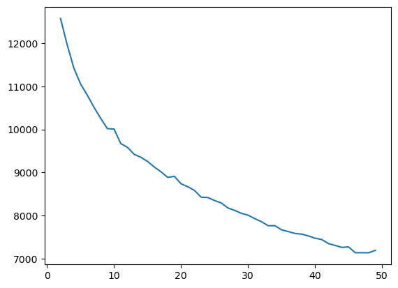

```python
inertias=[]
ks=range(2,50)
for k in ks:
    km=KMeans(n_clusters=k,n_init='auto')
    km.fit(foodFrame)
    inertias.append(km.inertia_)
plt.plot(ks,inertias)
plt.show()
```

To be honest, it's not obvious to me where the perfect number of clusters is. We're going to have to make a call here. I'm going to go with 15, and give it plenty of iterations to make sure we get a good clustering.

```python
km=KMeans(n_clusters=15,n_init=100)
km.fit(foodFrame)
```

```
KMeans(n_clusters=15, n_init=100)
```

How big are each of these 15 clusters?

```python
clustersize=[]
for cluster in range(15):
    clustersize.append(sum(km.labels_==cluster))
print(clustersize)
```

```
[24, 38, 31, 44, 38, 61, 38, 40, 24, 35, 49, 43, 38, 57, 43]
```

OK, so let's take a look at the biggest of these, cluster 5. Now, when I look at the 5th cluster center, it will give me an 18-dimensional point, which is the centroid of that cluster:

```python
km.cluster_centers_[5,:]
```

```
array([3.17854597, 2.45570459, 4.39756158, 3.56974067, 1.61501114,
       4.7811927 , 4.42765265, 3.34028813, 2.42937044, 4.42336891,
       3.90105187, 2.55295294, 4.05762377, 3.90987753, 4.2945082 ,
       1.99820346, 2.4593491 , 2.44755861])
```

For readability, I'll pair that up with column names:

```python
list(zip(foodFrame.columns,km.cluster_centers_[5,:]))
```

```
[('Broccoli', 3.178545972915182),
 ('Mushrooms', 2.4557045868521277),
 ('Beef Tacos', 4.397561578383722),
 ('Salads', 3.569740665606667),
 ('Black Licorice', 1.6150111384017822),
 ('Steak', 4.781192698212869),
 ('Grilled Chicken', 4.427652645118914),
 ('Mayonnaise', 3.3402881271733733),
 ('Candy Corn', 2.4293704366992697),
 ('Pulled Pork', 4.423368907470569),
 ('Spicy Mustard', 3.9010518659430424),
 ('Raw Oysters', 2.552952940819975),
 ('Bananas', 4.057623773233182),
 ('Avocado', 3.9098775329665774),
 ('Eggs', 4.294508196721312),
 ('Olives', 1.9982034583426902),
 ('Tofu', 2.4593491016877382),
 ('Cottage Cheese', 2.4475586109642165)]
```

OK, so there's a group of people who like those things about that amount. I'd like to compare them to the two next biggest clusters:

```python
firstcluster=km.cluster_centers_[5,:]
secondcluster=km.cluster_centers_[13,:]
thirdcluster=km.cluster_centers_[10,:]

fig=go.Figure()
fig.add_trace(go.Bar(x=foodFrame.columns, y=firstcluster, name='Biggest'))
fig.add_trace(go.Bar(x=foodFrame.columns, y=secondcluster, name='Other Biggest'))
fig.add_trace(go.Bar(x=foodFrame.columns, y=thirdcluster, name='Third Biggest'))

fig.show()
```

[interactive chart not shown]

Let's analyze this. Clearly, there's some agreement between these clusters. Some things are universally liked - steak and grilled chicken, for example. Nobody likes Black Licorice. There are differences, though! The third group seems to generally be the most favorable about these controversial foods, particularly when it comes to Olives, Tofu, and Cottage Cheese. The first group is pretty negative - in particular, it distinguishes itself with a negative view on Mushrooms and Olives.

Now, just for giggles, let's look at all our clusters. Tag yourself!

```python
for i in range(0,15,3):
    fig=go.Figure()
    fig.add_trace(go.Bar(x=foodFrame.columns, y=km.cluster_centers_[i,:], name=f'Cluster {i}'))
    fig.add_trace(go.Bar(x=foodFrame.columns, y=km.cluster_centers_[i+1,:], name=f'Cluster {i+1}'))
    fig.add_trace(go.Bar(x=foodFrame.columns, y=km.cluster_centers_[i+2,:], name=f'Cluster {i+2}'))

    fig.show()
```

[interactive chart not shown]

We can now think of this as saying that we don't have 603 users (which are all hard to think about), instead we have 15 *kinds* of users, which are all relatively similar within the same group.

## Was this even a good idea?

I'm not that sure. There is no clear number of clusters. How different are they, really? Let's take a look using the heirarchical information from **agglomerative clustering**.

To get the hierarchical plot, I'm just going to use some code from the sklearn Users Guide on agglomerative clustering.

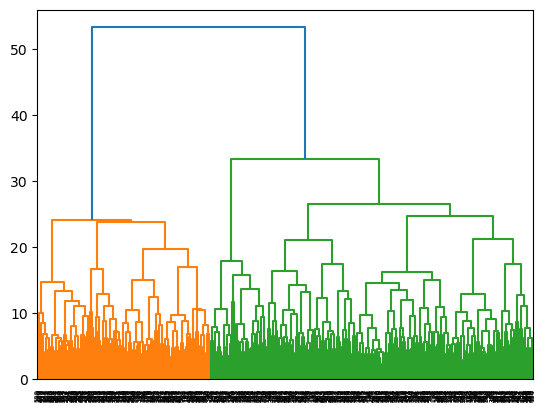

```python
from scipy.cluster.hierarchy import dendrogram
from sklearn.cluster import AgglomerativeClustering
import matplotlib.pyplot as plt

def plot_dendrogram(model, **kwargs):
    # Create linkage matrix and then plot the dendrogram

    # create the counts of samples under each node
    counts = np.zeros(model.children_.shape[0])
    n_samples = len(model.labels_)
    for i, merge in enumerate(model.children_):
        current_count = 0
        for child_idx in merge:
            if child_idx < n_samples:
                current_count += 1  # leaf node
            else:
                current_count += counts[child_idx - n_samples]
        counts[i] = current_count

    linkage_matrix = np.column_stack([model.children_, model.distances_,
                                      counts]).astype(float)

    # Plot the corresponding dendrogram
    dendrogram(linkage_matrix, **kwargs)

plt.rcParams.update(plt.rcParamsDefault)
ac=AgglomerativeClustering(distance_threshold=0, n_clusters=None)
ac.fit(foodFrame.to_numpy())
plot_dendrogram(ac, truncate_mode='level')
plt.show()
```

```python
km2=KMeans(n_clusters=2,n_init=50)
km2.fit(foodFrame)
```

```
KMeans(n_clusters=2, n_init=50)
```

```python
print('Number of elements in each cluster:',sum(km2.labels_==0),sum(km2.labels_==1))
fig=go.Figure()
fig.add_trace(go.Bar(x=foodFrame.columns, y=km2.cluster_centers_[0,:], name='First'))
fig.add_trace(go.Bar(x=foodFrame.columns, y=km2.cluster_centers_[1,:], name='Second'))

fig.show()
```

```
Number of elements in each cluster: 286 317
```

[interactive chart not shown]

OK, so that's two main clusters. The first group just likes food more. The main points of disagreement at USNA are over Mushrooms, Spicy Mustard, Raw Oysters, Olives, Tofu, and Cottage Cheese.

What if we decided the hierarchical plot above indicated three clusters?

```python
km3=KMeans(n_clusters=3,n_init=50)
km3.fit(foodFrame)
print(sum(km3.labels_==0),sum(km3.labels_==1),sum(km3.labels_==2))
fig=go.Figure()
fig.add_trace(go.Bar(x=foodFrame.columns, y=km3.cluster_centers_[0,:], name='First'))
fig.add_trace(go.Bar(x=foodFrame.columns, y=km3.cluster_centers_[1,:], name='Second'))
fig.add_trace(go.Bar(x=foodFrame.columns, y=km3.cluster_centers_[2,:], name='Second'))

fig.show()
```

```
219 181 203
```

[interactive chart not shown]

The second group is pretty different from the other two! Just a bunch of food sissies.

## In summation...

This is *unsupervised learning*. At the end of the day, we have **no idea** what "right" looks like - there's just information, from which we can draw informed conclusions. There has to be a smart, critical person in the loop. But, I think we've definitely learned something about this dataset!